# Elliptic Bitcoin Transactions Graph Dataset - Results

### *Experiment 2.1 - Boosting Algorithms vs Random Forest using Stratified Neighborhood Cleaning Rule (downsample)*

```python
###### importing dependencies #############################################
import matplotlib.pyplot as plt
from cryptoaml.utils import read_pickle
from IPython.core.display import display, HTML
from cryptoaml.metrics import (
    results_table,
    plot_metric_dist,
    plot_feature_imp,
    print_model_params,
    plot_result_matrices,
    display_metrics_stats,
    elliptic_time_indexed_results
)

###### constants ##########################################################
N_features              = 15 # for feature importance N top/bottom
EXP_RESULT_PATH         = "persistence/experiment_2.1/results"
BENCHMARK_RESULTS       = "{}/{}".format(EXP_RESULT_PATH, "benchmark_model_results.pkl")
BENCHMARK_TUNED_RESULTS = "{}/{}".format(EXP_RESULT_PATH, "tuned_benchmark_results.pkl")
DEFAULT_RESULTS         = "{}/{}".format(EXP_RESULT_PATH, "defaults_models_results.pkl")
TUNED_RESULTS           = "{}/{}".format(EXP_RESULT_PATH, "tuned_models_results.pkl")
```

## Benchmark Models

Experiment performed on the [elliptic dataset](https://www.kaggle.com/ellipticco/elliptic-data-set) [1,2]

Models were tested on the following feature sets:

- Local Features (LF)
- Local Features and Node Embeddings extracted from GCN (LF_NE)
- All Features - Aggregated Features and Local Features (AF)
- All Features and Node Embeddings extracted from GCN (AF_NE)

**Results obtained in the original paper [2]**

| Method | Illicit |  |  | MicroAVG |
| --- | --- | --- | --- | --- |
|  | Precision | Recall | F1 | F1 |
| LogReg (AF) | 0.404 | 0.593 | 0.481 | 0.931 |
| LogReg (AF+NE) | 0.537 | 0.528 | 0.533 | 0.945 |
| LogReg (LF) | 0.348 | 0.668 | 0.457 | 0.920 |
| LogReg (LF+NE) | 0.518 | 0.571 | 0.543 | 0.945 |
| RF (AF) | 0.956 | 0.670 | 0.788 | 0.977 |
| RF (AF+NE) | 0.971 | 0.675 | 0.796 | 0.978 |
| RF (LF) | 0.803 | 0.611 | 0.694 | 0.966 |
| RF (LF+NE) | 0.874 | 0.668 | 0.759 | 0.973 |
| MLP (AF) | 0.694 | 0.617 | 0.653 | 0.962 |
| MLP (AF+NE) | 0.780 | 0.617 | 0.689 | 0.967 |
| MLP (LF) | 0.637 | 0.662 | 0.649 | 0.958 |
| MLP (LF+NE) | 0.6819 | 0.5782 | 0.6258 | 0.986 |
| GCN | 0.812 | 0.512 | 0.628 | 0.961 |
| Skip-GCN | 0.812 | 0.623 | 0.705 | 0.966 |

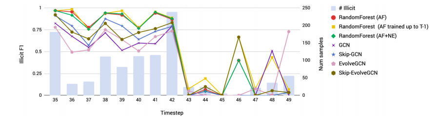

*Illicit F1 results over test time span from benchmark paper [2].*

### Random Forest - Default Hyperparameters

```python
# load results for benchmark model
benchmark_model = "random_forest"
benchmark_results = read_pickle(BENCHMARK_RESULTS)
```

#### RF Suggested Hyperparameters - Evaluation Metrics

- *Precision*
- *Recall*
- *F1*
- *F1 Micro Avg/Accuracy*
- AUC

*Italics text refers to metrics which were used in the benchmark paper. The results reproduce are very close to the ones documented in the benchmark paper [2], shown in the previous section. In our test run we managed to obtain higher results using the same hyperparameters specified.*

```python
# dataframe with all the perfomance metrics
print("Performance metrics for benchmark model")
benchmark_metrics_df = results_table(benchmark_results)
display(benchmark_metrics_df)

# sorted by f1 score
print("Performance metrics for benchmark model sorted by f1-score")
display(benchmark_metrics_df.sort_values("f1", ascending=False))
```

```
Performance metrics for benchmark model
```

|  | model | precision | recall | f1_micro | accuracy | auc | f1 |
| --- | --- | --- | --- | --- | --- | --- | --- |
| 0 | random_forest_AF | 0.939 | 0.726 | 0.979 | 0.979 | 0.861 | 0.819 |
| 1 | random_forest_AF_NE | 0.972 | 0.721 | 0.981 | 0.981 | 0.860 | 0.828 |

```
Performance metrics for benchmark model sorted by f1-score
```

|  | model | precision | recall | f1_micro | accuracy | auc | f1 |
| --- | --- | --- | --- | --- | --- | --- | --- |
| 1 | random_forest_AF_NE | 0.972 | 0.721 | 0.981 | 0.981 | 0.860 | 0.828 |
| 0 | random_forest_AF | 0.939 | 0.726 | 0.979 | 0.979 | 0.861 | 0.819 |

#### RF Default Hyperparameters - Evaluation Statistics

*Note: Since random forest is non-deterministic in nature, we ran the model for 100 iterations and averaged the results. This was done to insure robustness and was also recommended in previous studies.*

Below we show statistics for the evaluation metrics.

```
'random_forest' on 'AF' feature set - performance metrics stats
```

|  | iteration | precision | recall | f1_micro | accuracy | auc | f1 |
| --- | --- | --- | --- | --- | --- | --- | --- |
| count | 100.000000 | 100.000000 | 100.000000 | 100.000000 | 100.000000 | 100.000000 | 100.000000 |
| mean | 49.500000 | 0.939451 | 0.725679 | 0.979135 | 0.979135 | 0.861212 | 0.818821 |
| std | 29.011492 | 0.008642 | 0.002113 | 0.000448 | 0.000448 | 0.001013 | 0.003207 |
| min | 0.000000 | 0.910776 | 0.721145 | 0.977564 | 0.977564 | 0.859097 | 0.807811 |
| 25% | 24.750000 | 0.935618 | 0.723915 | 0.978884 | 0.978884 | 0.860378 | 0.817190 |
| 50% | 49.500000 | 0.940048 | 0.725762 | 0.979154 | 0.979154 | 0.861142 | 0.818890 |
| 75% | 74.250000 | 0.944495 | 0.726685 | 0.979439 | 0.979439 | 0.861811 | 0.821149 |
| max | 99.000000 | 0.956151 | 0.732225 | 0.980024 | 0.980024 | 0.864573 | 0.825380 |

```
'random_forest' on 'AF_NE' feature set - performance metrics stats
```

|  | iteration | precision | recall | f1_micro | accuracy | auc | f1 |
| --- | --- | --- | --- | --- | --- | --- | --- |
| count | 100.000000 | 100.000000 | 100.000000 | 100.000000 | 100.000000 | 100.000000 | 100.000000 |
| mean | 49.500000 | 0.972095 | 0.720997 | 0.980528 | 0.980528 | 0.859779 | 0.827920 |
| std | 29.011492 | 0.004098 | 0.002458 | 0.000245 | 0.000245 | 0.001222 | 0.002100 |
| min | 0.000000 | 0.960640 | 0.714681 | 0.979664 | 0.979664 | 0.856378 | 0.820350 |
| 25% | 24.750000 | 0.969050 | 0.719298 | 0.980429 | 0.980429 | 0.858943 | 0.826964 |
| 50% | 49.500000 | 0.972534 | 0.721145 | 0.980564 | 0.980564 | 0.859899 | 0.828025 |
| 75% | 74.250000 | 0.975031 | 0.722992 | 0.980684 | 0.980684 | 0.860638 | 0.829210 |
| max | 99.000000 | 0.980000 | 0.725762 | 0.981104 | 0.981104 | 0.862303 | 0.833068 |

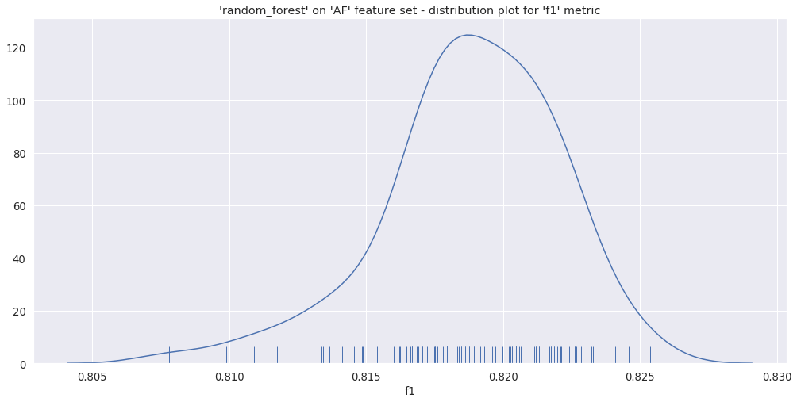

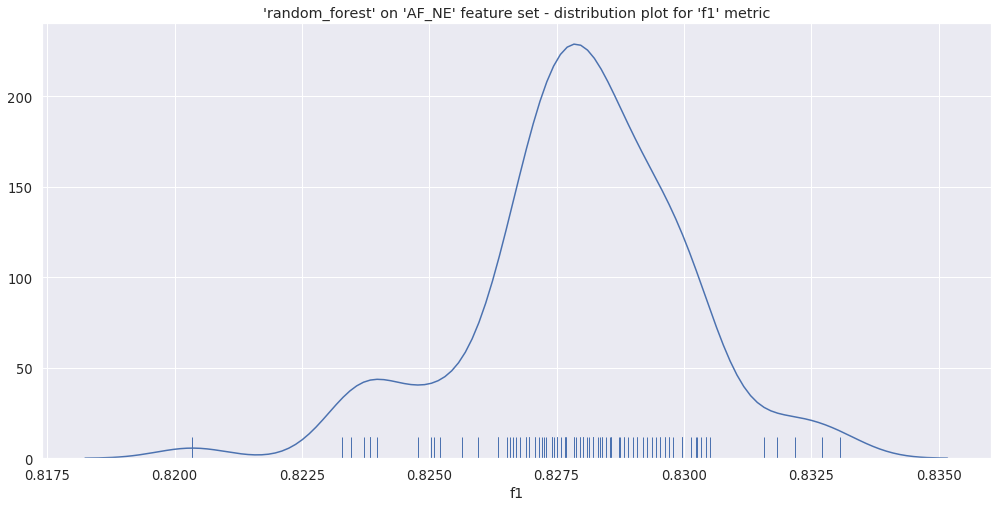

```python
# display stats for each metric for benchmark model over 100 runs
display_metrics_stats(benchmark_results)

# plot f1 score distribution for benchmark model over 100 runs
plot_metric_dist(benchmark_results, "f1", figsize=(17,8))
```

#### RF Default Hyperparameters - Confusion Matrix

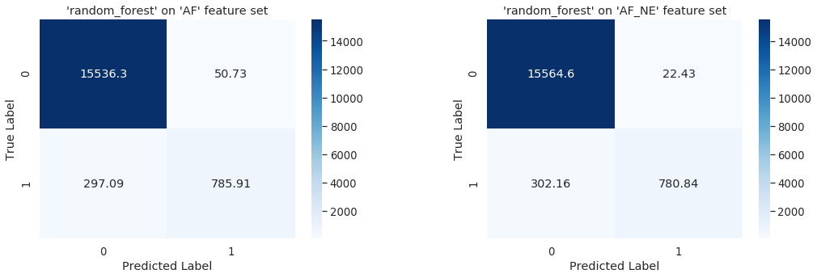

```python
plot_result_matrices(benchmark_results, figsize=(17,5))
```

#### RF Default Hyperparameters - F1 Results over Test Span

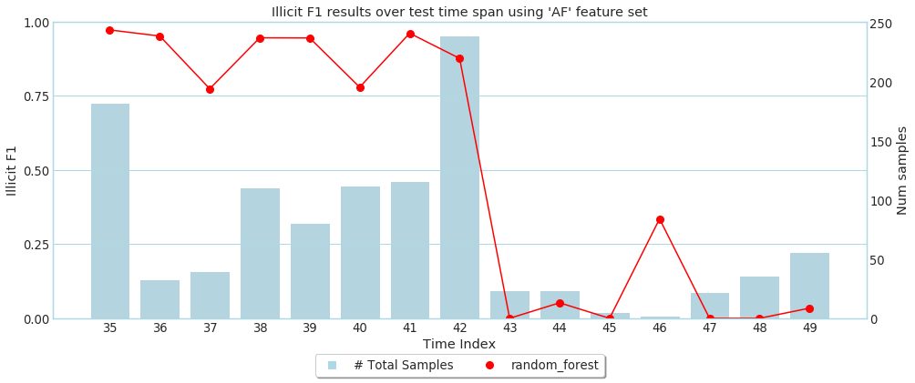

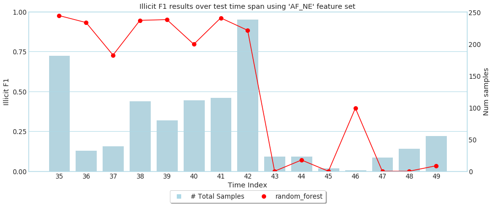

```python
elliptic_time_indexed_results(benchmark_results)
```

#### RF Default Hyperparameters - Feature Importance

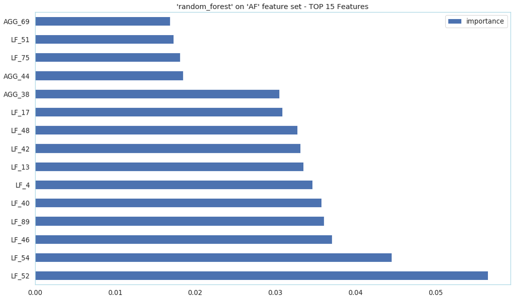

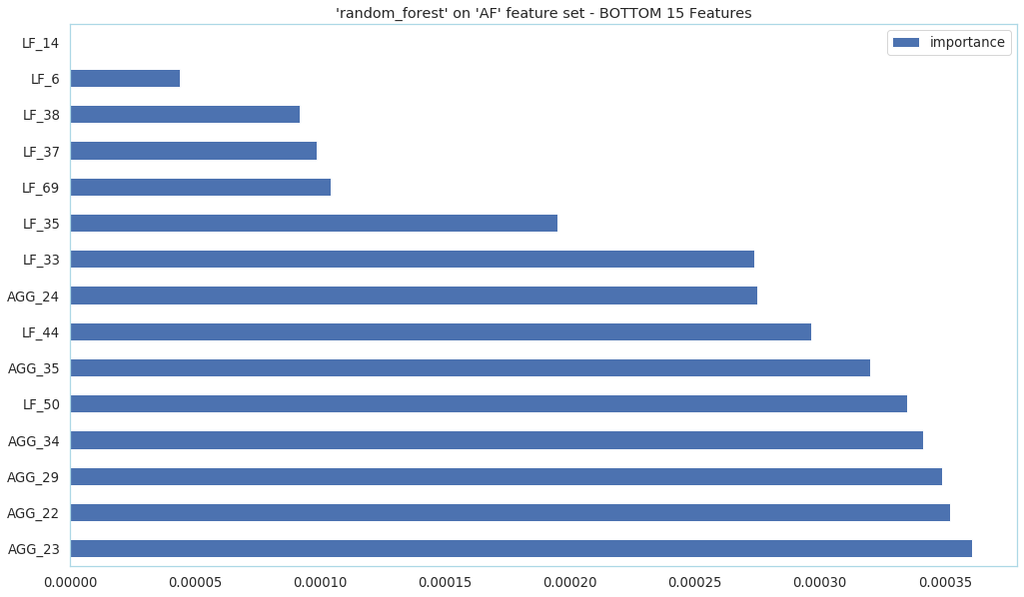

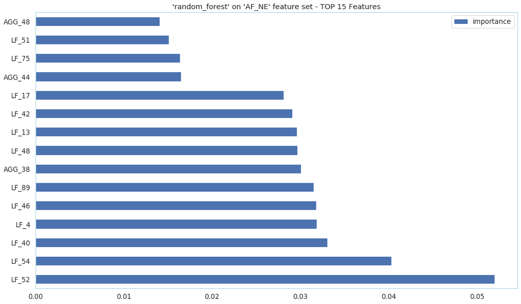

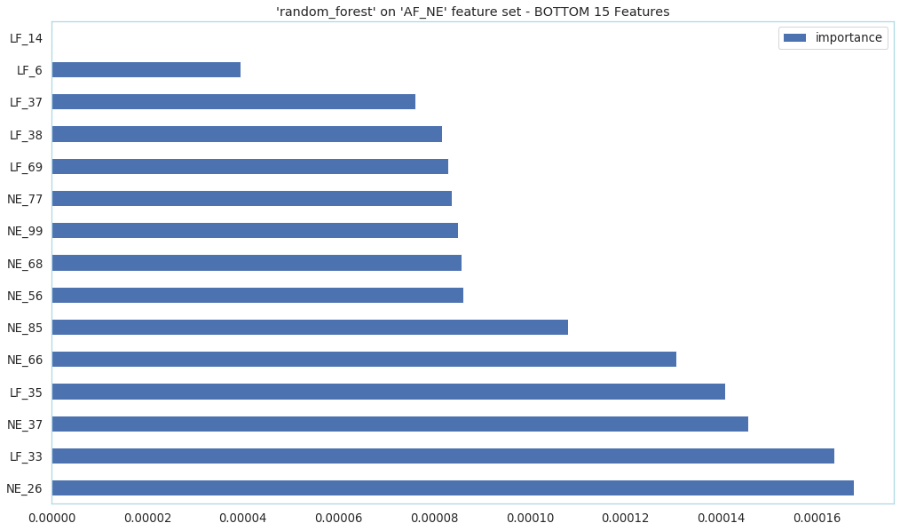

```python
plot_feature_imp(benchmark_results, N_features)
```

#### RF Default Hyperparameters - Hyperparameters

```python
print_model_params(benchmark_results)
```

```
Parameters used for 'random_forest' on 'AF' feature set
{   'bootstrap': True,
    'ccp_alpha': 0.0,
    'class_weight': None,
    'criterion': 'gini',
    'max_depth': None,
    'max_features': 'auto',
    'max_leaf_nodes': None,
    'max_samples': None,
    'min_impurity_decrease': 0.0,
    'min_impurity_split': None,
    'min_samples_leaf': 1,
    'min_samples_split': 2,
    'min_weight_fraction_leaf': 0.0,
    'n_estimators': 100,
    'n_jobs': 16,
    'oob_score': False,
    'random_state': None,
    'verbose': 0,
    'warm_start': False}
```

```
Parameters used for 'random_forest' on 'AF_NE' feature set
{   'bootstrap': True,
    'ccp_alpha': 0.0,
    'class_weight': None,
    'criterion': 'gini',
    'max_depth': None,
    'max_features': 'auto',
    'max_leaf_nodes': None,
    'max_samples': None,
    'min_impurity_decrease': 0.0,
    'min_impurity_split': None,
    'min_samples_leaf': 1,
    'min_samples_split': 2,
    'min_weight_fraction_leaf': 0.0,
    'n_estimators': 100,
    'n_jobs': 16,
    'oob_score': False,
    'random_state': None,
    'verbose': 0,
    'warm_start': False}
```

### Random Forest - Tuned Hyperparameters

```python
benchmark_tuned_results = read_pickle(BENCHMARK_TUNED_RESULTS)
```

#### RF Tuned Hyperparameters - Evaluation Metrics

- *Precision*
- *Recall*
- *F1*
- *F1 Micro Avg/Accuracy*
- AUC

*Italics text refers to metrics which were used in the benchmark paper.*

```python
print("Performance metrics for RF benchmark model with tuned hyperparameters")
benchmark_tuned_metrics_df = results_table(benchmark_tuned_results)
display(benchmark_tuned_metrics_df)
```

```
Performance metrics for RF benchmark model with tuned hyperparameters
```

|  | model | precision | recall | f1_micro | accuracy | auc | f1 |
| --- | --- | --- | --- | --- | --- | --- | --- |
| 0 | random_forest_AF | 0.946 | 0.726 | 0.980 | 0.980 | 0.862 | 0.822 |
| 1 | random_forest_AF_NE | 0.977 | 0.723 | 0.981 | 0.981 | 0.861 | 0.831 |

#### RF Tuned Hyperparameters - Evaluation Statistics

*Note: Since random forest is non-deterministic in nature, we ran the model for 100 iterations and averaged the results. This was done to insure robustness and was also recommended in previous studies.*

Below we show statistics for the evaluation metrics.

```
'random_forest' on 'AF' feature set - performance metrics stats
```

|  | iteration | precision | recall | f1_micro | accuracy | auc | f1 |
| --- | --- | --- | --- | --- | --- | --- | --- |
| count | 100.000000 | 100.000000 | 100.000000 | 100.000000 | 100.000000 | 100.000000 | 100.000000 |
| mean | 49.500000 | 0.946486 | 0.726103 | 0.979538 | 0.979538 | 0.861625 | 0.821773 |
| std | 29.011492 | 0.003056 | 0.001005 | 0.000169 | 0.000169 | 0.000502 | 0.001283 |
| min | 0.000000 | 0.938021 | 0.723915 | 0.979124 | 0.979124 | 0.860418 | 0.818799 |
| 25% | 24.750000 | 0.944712 | 0.725762 | 0.979424 | 0.979424 | 0.861365 | 0.820888 |
| 50% | 49.500000 | 0.946924 | 0.725762 | 0.979544 | 0.979544 | 0.861534 | 0.821746 |
| 75% | 74.250000 | 0.948208 | 0.726685 | 0.979664 | 0.979664 | 0.861963 | 0.822606 |
| max | 99.000000 | 0.953883 | 0.728532 | 0.979904 | 0.979904 | 0.862854 | 0.824699 |

```
'random_forest' on 'AF_NE' feature set - performance metrics stats
```

|  | iteration | precision | recall | f1_micro | accuracy | auc | f1 |
| --- | --- | --- | --- | --- | --- | --- | --- |
| count | 100.000000 | 100.000000 | 100.000000 | 100.000000 | 100.000000 | 100.000000 | 100.000000 |
| mean | 49.500000 | 0.976682 | 0.723066 | 0.980887 | 0.980887 | 0.860933 | 0.830951 |
| std | 29.011492 | 0.002151 | 0.001149 | 0.000125 | 0.000125 | 0.000573 | 0.001057 |
| min | 0.000000 | 0.971429 | 0.720222 | 0.980564 | 0.980564 | 0.859565 | 0.828390 |
| 25% | 24.750000 | 0.975093 | 0.722068 | 0.980804 | 0.980804 | 0.860481 | 0.830329 |
| 50% | 49.500000 | 0.976339 | 0.722992 | 0.980864 | 0.980864 | 0.860886 | 0.830949 |
| 75% | 74.250000 | 0.978697 | 0.723915 | 0.980939 | 0.980939 | 0.861348 | 0.831568 |
| max | 99.000000 | 0.982434 | 0.725762 | 0.981224 | 0.981224 | 0.862368 | 0.833952 |

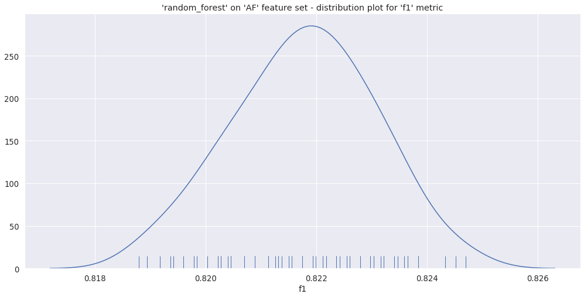

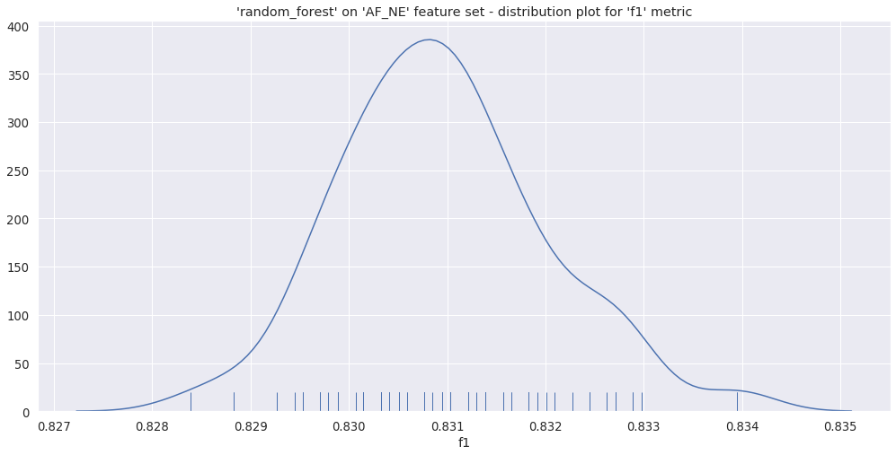

```python
display_metrics_stats(benchmark_tuned_results)
plot_metric_dist(benchmark_tuned_results, "f1", figsize=(17,8))
```

#### RF Tuned Hyperparameters - Confusion Matrix

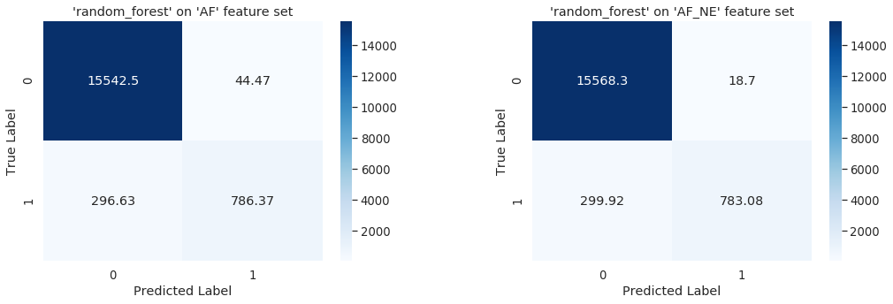

```python
plot_result_matrices(benchmark_tuned_results, figsize=(17,5))
```

#### RF Tuned Hyperparameters - F1 Results over Test Span

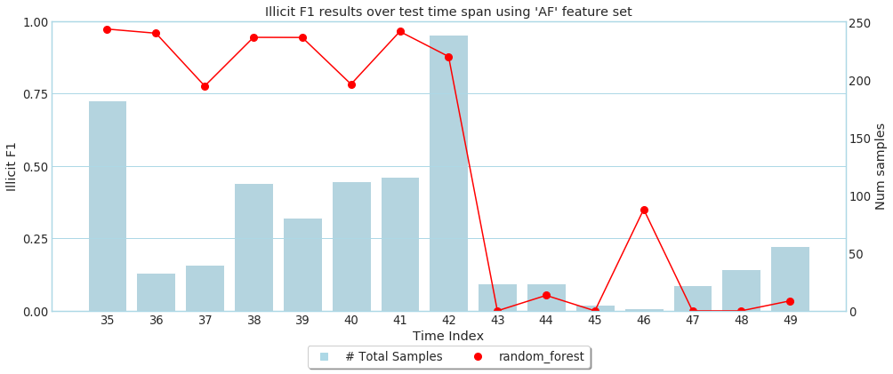

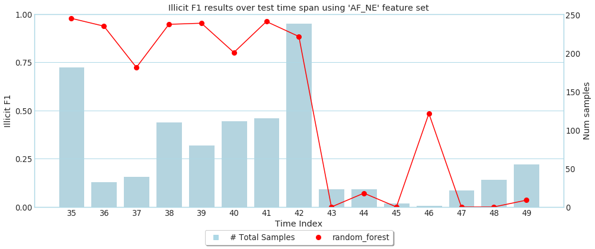

```python
elliptic_time_indexed_results(benchmark_tuned_results)
```

#### RF Tuned Hyperparameters - Feature Importance

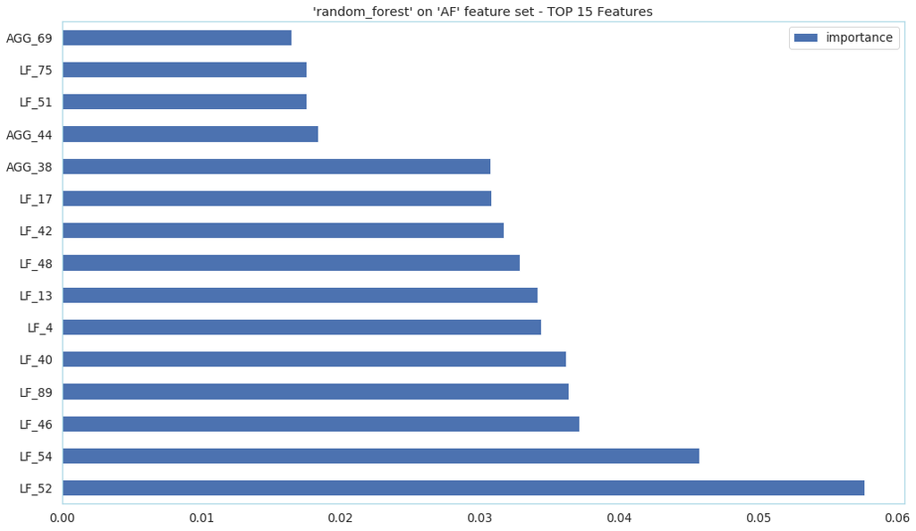

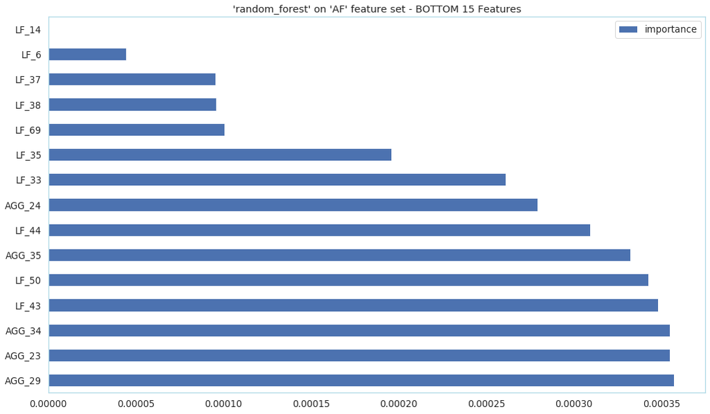

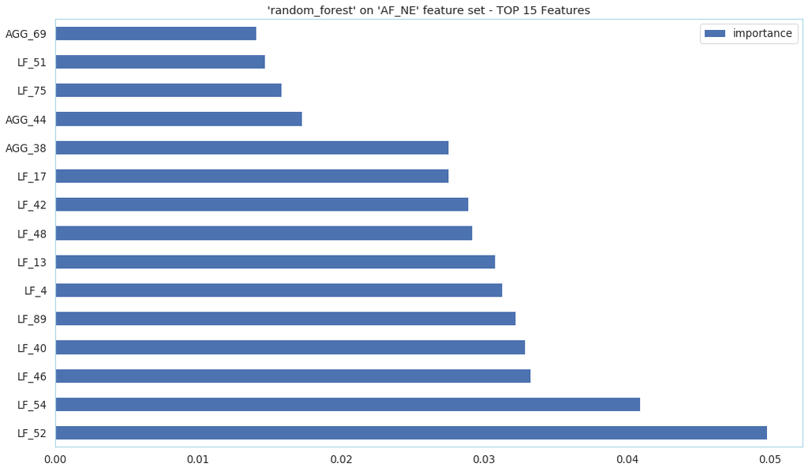

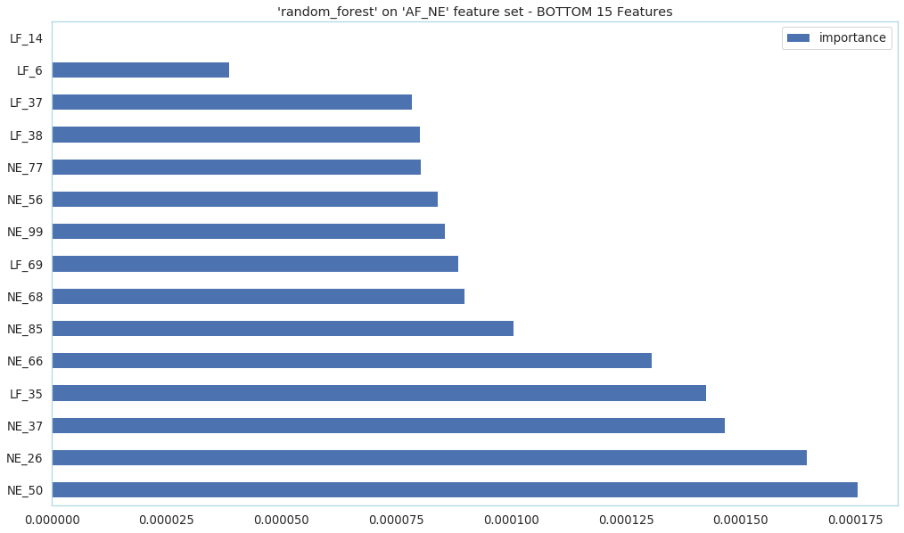

```python
plot_feature_imp(benchmark_tuned_results, N_features)
```

#### RF Tuned Hyperparameters - Hyperparameters

```python
print_model_params(benchmark_tuned_results)
```

```
Parameters used for 'random_forest' on 'AF' feature set
{   'bootstrap': True,
    'ccp_alpha': 0.0,
    'class_weight': None,
    'criterion': 'gini',
    'max_depth': None,
    'max_features': 'sqrt',
    'max_leaf_nodes': None,
    'max_samples': 0.997743561132347,
    'min_impurity_decrease': 0.0,
    'min_impurity_split': None,
    'min_samples_leaf': 1,
    'min_samples_split': 2,
    'min_weight_fraction_leaf': 0.0,
    'n_estimators': 950,
    'n_jobs': 16,
    'oob_score': False,
    'random_state': None,
    'verbose': 0,
    'warm_start': False}
```

```
Parameters used for 'random_forest' on 'AF_NE' feature set
{   'bootstrap': True,
    'ccp_alpha': 0.0,
    'class_weight': None,
    'criterion': 'gini',
    'max_depth': None,
    'max_features': 'sqrt',
    'max_leaf_nodes': None,
    'max_samples': 0.9460836512710245,
    'min_impurity_decrease': 0.0,
    'min_impurity_split': None,
    'min_samples_leaf': 1,
    'min_samples_split': 2,
    'min_weight_fraction_leaf': 0.0,
    'n_estimators': 800,
    'n_jobs': 16,
    'oob_score': False,
    'random_state': None,
    'verbose': 0,
    'warm_start': False}
```

## Boosting Algorithms

- [XGBoost: eXtreme Gradient Boosting](https://xgboost.readthedocs.io/en/latest/)
- [LightGBM: Light Gradient Boosting Machine](https://lightgbm.readthedocs.io/en/latest/)
- [CatBoost](https://catboost.ai/)

### Boosting Algorithms - Default Hyperparameters

```python
default_results = read_pickle(DEFAULT_RESULTS)
```

#### Boosting Default Hyperparameters - Evaluation Metrics

- *Precision*
- *Recall*
- *F1*
- *F1 Micro Avg/Accuracy*
- AUC

*Italics text refers to metrics which were used in the benchmark paper.*

```python
print("Performance metrics for defaults boosting models")
defaults_metrics_df = results_table(default_results)
display(defaults_metrics_df)

print("Performance metrics for defaults boosting models sorted by f1-score")
display(defaults_metrics_df.sort_values("f1", ascending=False))
```

```
Performance metrics for defaults boosting models
```

|  | model | precision | recall | f1_micro | accuracy | auc | f1 |
| --- | --- | --- | --- | --- | --- | --- | --- |
| 0 | xg_boost_AF | 0.877 | 0.721 | 0.975 | 0.975 | 0.857 | 0.791 |
| 1 | xg_boost_AF_NE | 0.978 | 0.698 | 0.979 | 0.979 | 0.848 | 0.815 |
| 2 | light_boost_AF | 0.889 | 0.722 | 0.976 | 0.976 | 0.858 | 0.797 |
| 3 | light_boost_AF_NE | 0.972 | 0.705 | 0.979 | 0.979 | 0.852 | 0.817 |
| 4 | cat_boost_AF | 0.946 | 0.725 | 0.979 | 0.979 | 0.861 | 0.821 |
| 5 | cat_boost_AF_NE | 0.980 | 0.696 | 0.979 | 0.979 | 0.848 | 0.814 |

```
Performance metrics for defaults boosting models sorted by f1-score
```

|  | model | precision | recall | f1_micro | accuracy | auc | f1 |
| --- | --- | --- | --- | --- | --- | --- | --- |
| 4 | cat_boost_AF | 0.946 | 0.725 | 0.979 | 0.979 | 0.861 | 0.821 |
| 3 | light_boost_AF_NE | 0.972 | 0.705 | 0.979 | 0.979 | 0.852 | 0.817 |
| 1 | xg_boost_AF_NE | 0.978 | 0.698 | 0.979 | 0.979 | 0.848 | 0.815 |
| 5 | cat_boost_AF_NE | 0.980 | 0.696 | 0.979 | 0.979 | 0.848 | 0.814 |
| 2 | light_boost_AF | 0.889 | 0.722 | 0.976 | 0.976 | 0.858 | 0.797 |
| 0 | xg_boost_AF | 0.877 | 0.721 | 0.975 | 0.975 | 0.857 | 0.791 |

#### Boosting Default Hyperparameters - Confusion Matrices

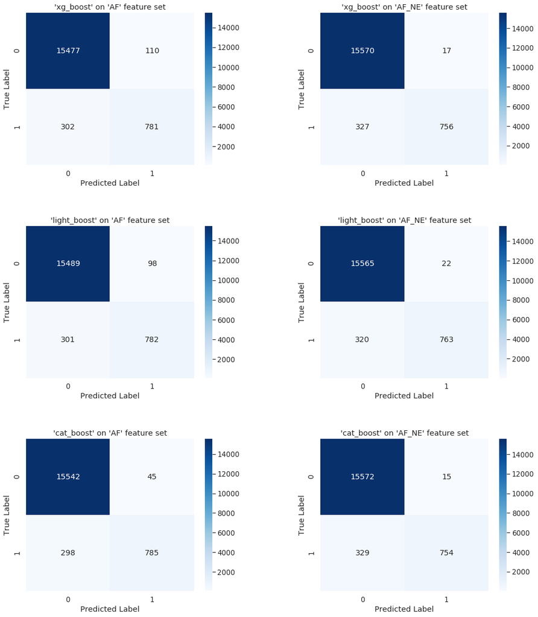

```python
plot_result_matrices(default_results, figsize=(17,20))
```

#### Boosting Default Hyperparameters - F1 Results over Test Span

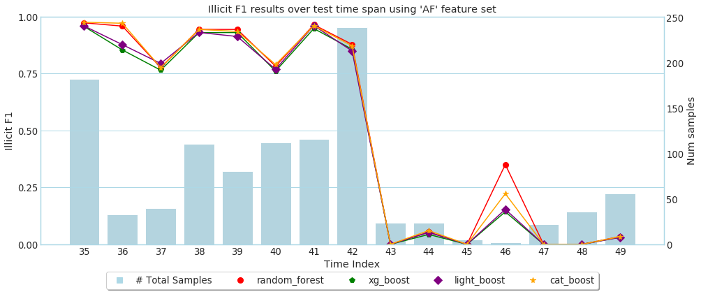

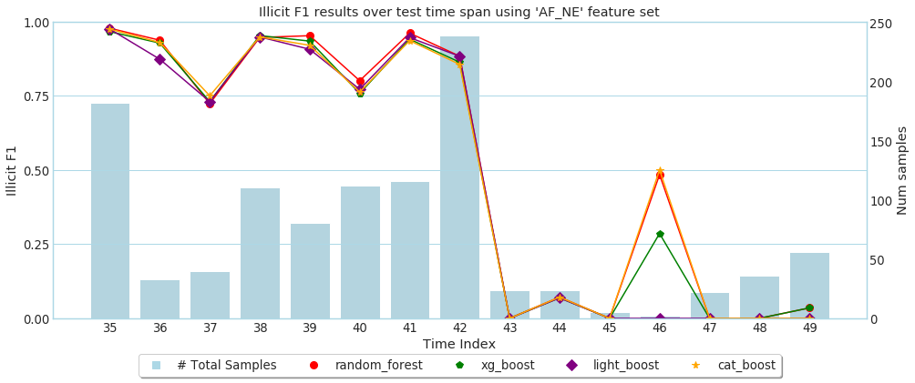

```python
# in this plot we also display benchmark model
tmp_results = {**benchmark_tuned_results, **default_results}
elliptic_time_indexed_results(tmp_results)
```